# Praca domowa 2

Bruno Tomusiak

## Dane

Dane wykorzystane w Pracy domowej 2 są związane z kampaniami marketingu bezpośredniego portugalskiej instytucji bankowej. Kampanie marketingowe opierały się na rozmowach telefonicznych. Często wymagany był więcej niż jeden kontakt z tym samym klientem, aby uzyskać dostęp do tego, czy produkt (lokata bankowa) zostanie (lub nie) subskrybowany. Opis wszystkich kolumn znajduje się również w pliku `README.md`.

#### Dane klienta banku

| Zmienna | Opis |
| --- | --- |
| **age** | wiek |
| **job** : admin., unknown, unemployed, management, housemaid, entrepreneur, student, blue-collar, self-employed, retired, technician, services | administrator, nieznany, bezrobotny, kierownictwo, pokojówka, przedsiębiorca, student, pracownik fizyczny, samozatrudniony, emeryt, technik, usługi |
| **marital** : married, divorced, single; note: divorced means divorced or widowed) | żonaty/zamężna, rozwiedzion_, kawaler/panna; uwaga: rozwiedzion_ oznacza rozwiedzion_ lub owdowiał_ |
| **education** : unknown, secondary, primary, tertiary | nieznane, średnie, podstawowe, wyższe |
| **default** : yes, no | czy kredyt jest niespłacany : tak, nie |
| **balance** : average yearly balance, in euros | średnie roczne saldo w euro |
| **housing** : has housing loan? yes, no | czy posiada kredyt mieszkaniowy? tak, nie |
| **loan** : has personal loan? yes, no | ma pożyczkę osobistą? tak, nie |

#### Dane związane z ostatnim kontaktem w bieżącej kampanii

| Zmienna | Opis |
| --- | --- |
| **contact** : unknown, telephone, cellular | nieznany, telefon, komórkowy |
| **day** : last contact day of the month | dzień miesiąca ostatniego kontaktu |
| **month** : last contact month of year, jan, feb, mar, …, nov, dec | miesiąc ostatniego kontaktu w roku, styczeń, luty, marzec, …, listopad, grudzień |
| **duration** : last contact duration, in seconds | czas trwania ostatniego kontaktu w sekundach |

## Zadanie 1

Weźmy pod uwagę zawody (`job`) klientów banku. Który zawód zacząco wyróżnia się w posiadaniu kredytu mieszkaniowego lub pożyczki osobistej?

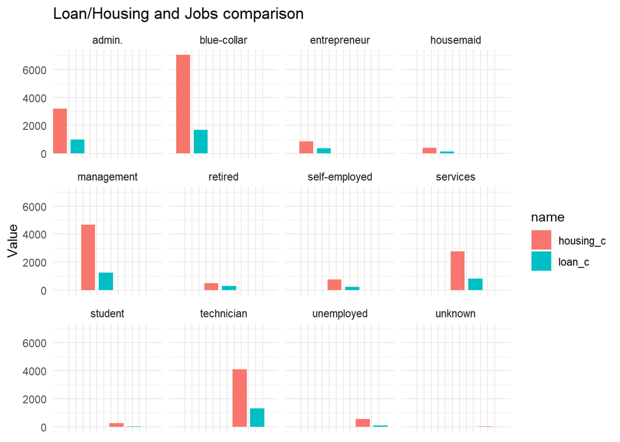

```r
df %>%
  select(c(job,housing,loan)) %>%
  group_by(job) %>%
  summarise(
    housing_c = sum(housing == 'yes', na.rm = TRUE),
    loan_c = sum(loan == 'yes', na.rm = TRUE)
  ) %>%
  pivot_longer(cols = c(housing_c,loan_c)) -> z1_data


z1_data %>%
  ggplot(aes(x=job,y=value, fill = name))+
  geom_bar(stat = 'identity', position = position_dodge(width = 5), width = 4)+
  facet_wrap(~job)+
  labs(title = 'Loan/Housing and Jobs comparison',
       x = NULL,
       y = 'Value')+
  scale_x_discrete(labels = NULL)+
  theme_minimal()
```

**Komentarz: Na tle wszystkich zawodów zdecydowanie wyróżnia się zawód - pracownik fizyczny (blue collar) warte uwagi są również zawody: technik, oraz kierownictwo**

## Zadanie 2

Wybierając klientów, którzy mają nieznany sposób kontaktu (`contact`). Jak rozkłada się ich wiek w podziale na status związku?

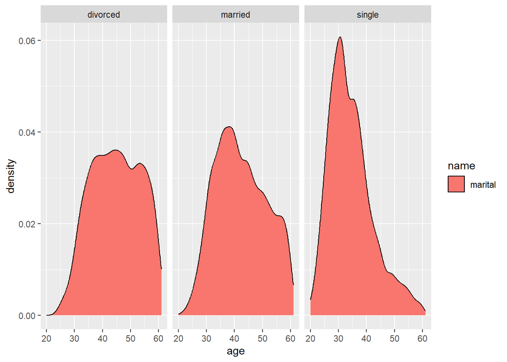

```r
df %>%
  filter(contact == 'unknown') %>%
  select(c(age, marital)) %>%
  pivot_longer(cols = marital) %>%
  ggplot(aes(x = age, fill = name))+
  geom_density()+
  facet_wrap(~value)
```

**Komentarz: widać, że najwięcej singli jest w wieku około 30 lat, a potem ich liczba drastycznie maleje,pozostałe dwa rozkłady są dosyć do siebie podobne**

## Zadanie 3

Jaka jest różnica pomiędzy średnim rocznym saldem w euro w zależności od wykształcenia i tego czy kredyt jest niespłacany?

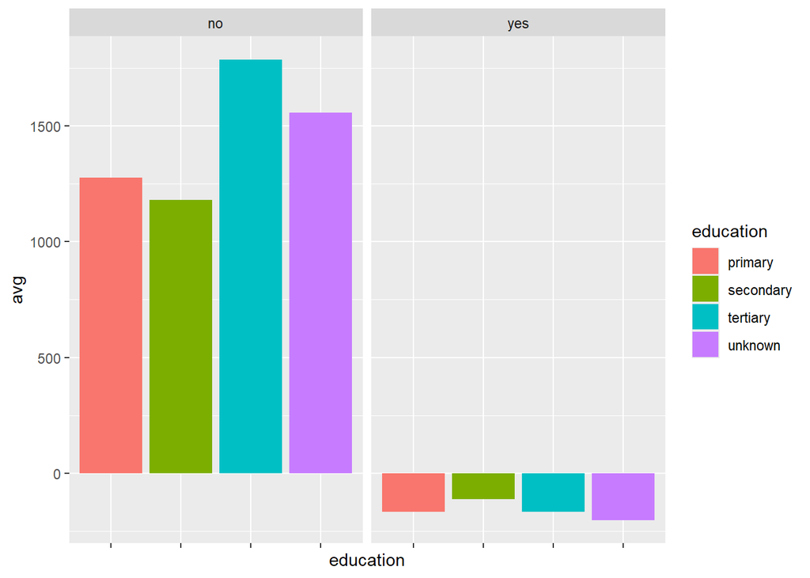

```r
df %>%
  select(c(education,default,balance))%>%
  group_by(education,default) %>%
  summarise(avg = mean(balance)) %>%
  ggplot(aes(x = education,y = avg, fill = education ))+
  geom_bar(stat = 'identity')+
  facet_wrap(~default)+
  scale_x_discrete(labels = NULL)
```

## Zadanie 4

Czy dzień i miesiąc kontaktu z klientem ma wpływ na średni czas trwania rozmowy w stosunku do średniego czasu trwania rozmowy?

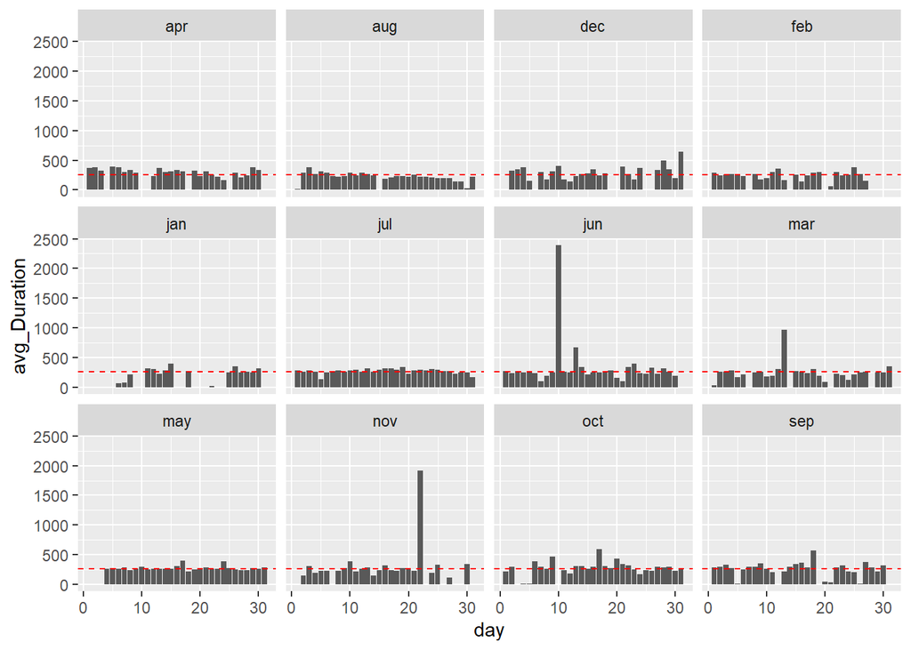

```r
df %>%
  select(day, month,duration) %>%
  group_by(day, month) %>%
  summarise(avg_Duration = mean(duration, na.rm = TRUE)) %>%
  ggplot(aes(x = day,y = avg_Duration))+
  geom_bar(stat = 'identity')+
  geom_hline(yintercept = mean(df$duration), linetype = "dashed", color = "red")+
  facet_wrap(~month)
```

**Komentarz: z reguły rozkład jest równomierny, jedynie trzy miesiące mają znaczący wzrot w pewnym dniu. Czerwona linia oznacza średnią!**

## Zadanie 5

Czy jest zależnośc pomiędzy wiekiem klientów a ich średnim rocznym saldzie w euro w podziale na stopień wykształcenia?

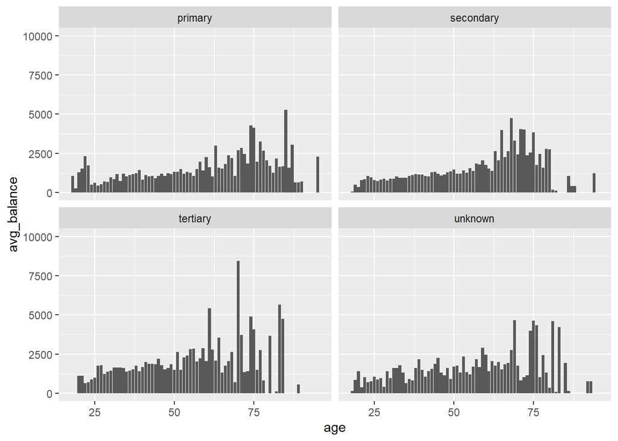

```r
df %>%
  select(age, balance, education) %>%
  group_by(age, education) %>%
  summarise(avg_balance = mean(balance)) %>%
  ggplot(aes(x = age, y = avg_balance))+
  geom_col()+
  facet_wrap(~education)+
  ylim(0,10000)
```

**Komentarz: po eleminacji obserwacji, która znacząco odstawała od reszty, co sugeruje niepoprawność danych tendencja jest wówczas rosnąca, wraz z wiekiem wzrasta średnie roczne saldo**

## Zadanie 6

Rozważmy osoby, które są bezrobotne albo ich zawód jest nieznany. Czy procent osób, które są bezrobotne i nie spłacają kredytu jest większy od procenta osób o nieznanym zawodzie i nie spłacanym kredycie? Jaki typ kredytu jest (przez te osoby) najczęściej niespłacany?

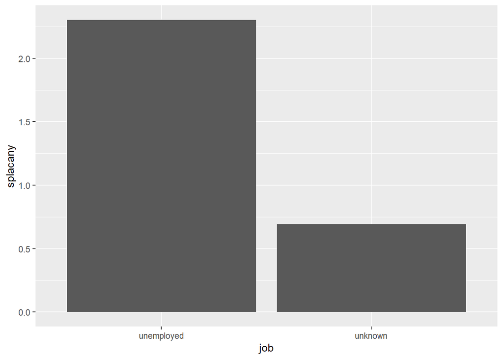

```r
df %>%
  filter(job %in% c('unknown', 'unemployed')) %>%
  select(job, default, loan, housing) %>%
  group_by(job) %>%
  summarise(splacany = 100*mean(default == 'yes')) %>%
  ggplot(aes(x = job, y = splacany))+
  geom_col()
```

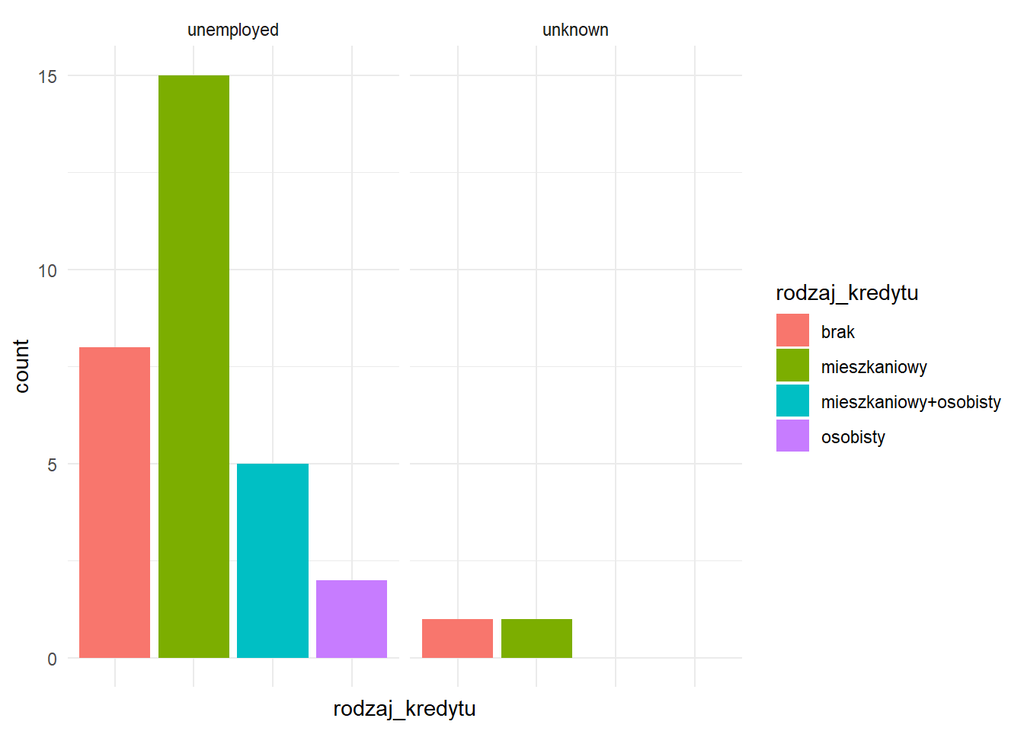

```r
df %>%
  filter(job %in% c('unknown', 'unemployed')) %>%
  select(job, default, loan, housing) %>%
  filter(default == 'yes') %>%
  group_by(job) %>%
  mutate(rodzaj_kredytu = case_when(
    housing == 'yes'& loan == 'yes' ~ 'mieszkaniowy+osobisty',
    housing == 'yes' ~ 'mieszkaniowy',
    loan == 'yes' ~ 'osobisty',
    TRUE ~ 'brak'
  )) %>%
  ggplot(aes(x = rodzaj_kredytu, fill = rodzaj_kredytu))+
  geom_bar()+
  facet_wrap(~job)+
  theme_minimal()+
  scale_x_discrete(labels = NULL)
```

**Komentarz: procent bezrobotnych, którzy nie spłacają kredytu jest większy od drugiej rozważanej grupy zawodowej. Bezrobotni najczęściej nie spłacają kredytu mieszkaniowego, u drugiej grupy występują tylko dwa rodzaje na takim samym poziomie**